# Joint conf-call report #2

## 100 samples SGD test

### 100 samples SGD test - iterations over time

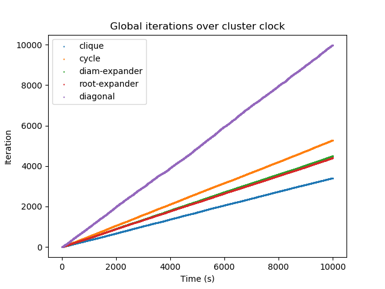

### 100 samples SGD test - MSE over iterations

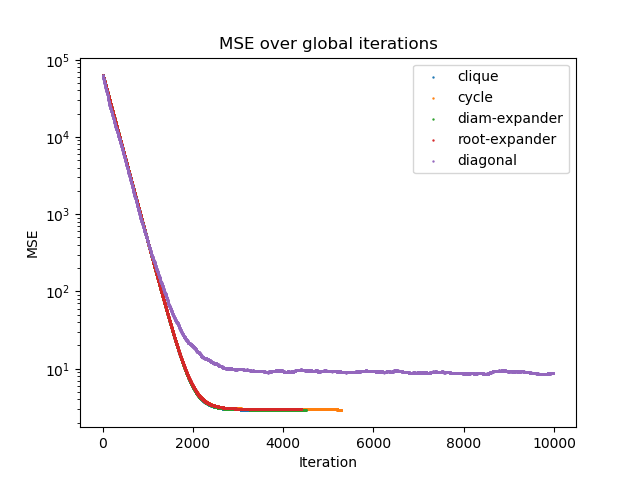

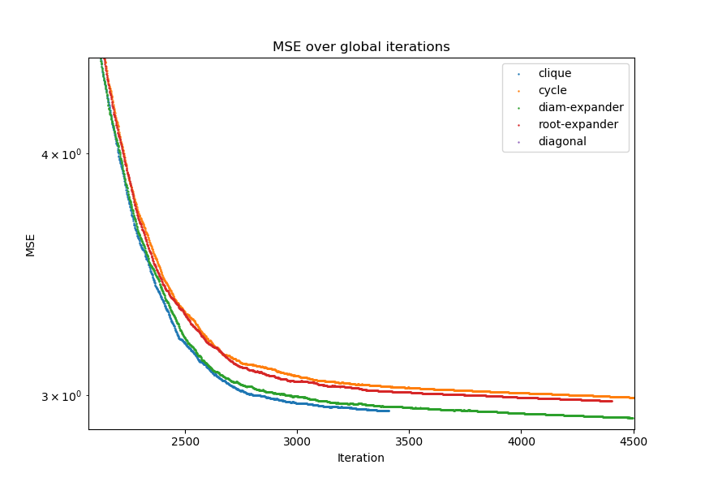

### 100 samples SGD test - RMSE over iterations

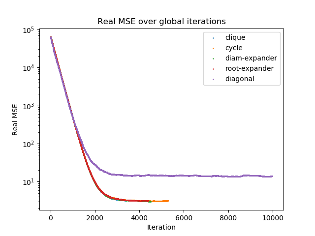

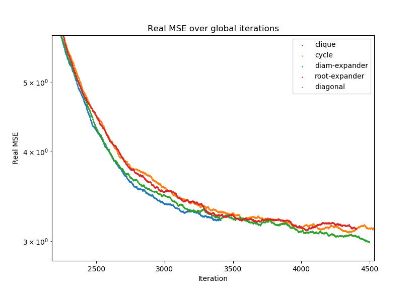

### 100 samples SGD test - MSE over time

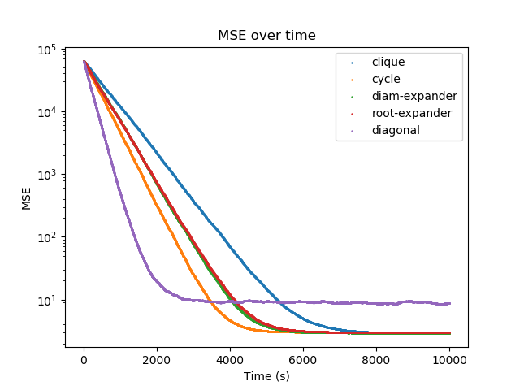

### 100 samples SGD test - RMSE over time

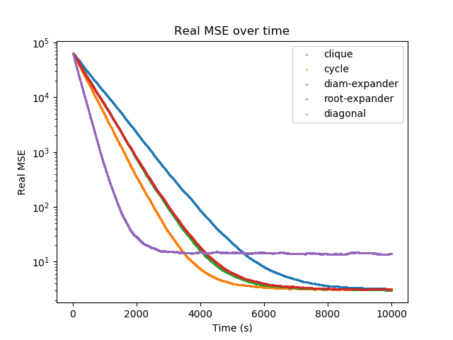

## 1k samples SGD test

### 1k samples SGD test - iterations over time

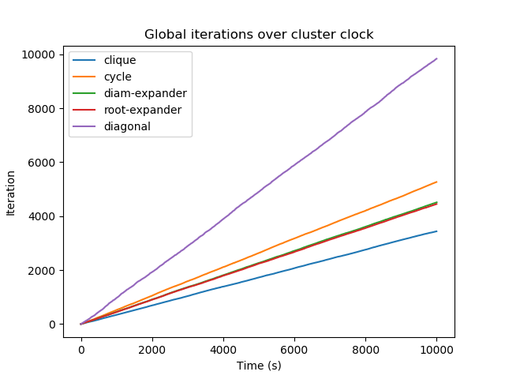

### 1k samples SGD test - MSE over iterations

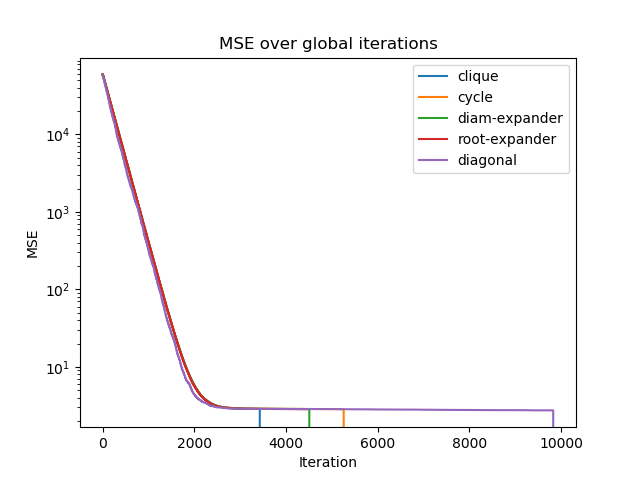

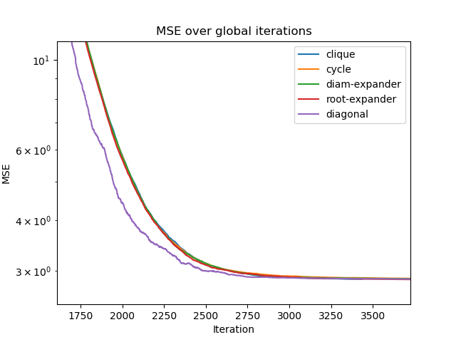

### 1k samples SGD test - RMSE over iterations

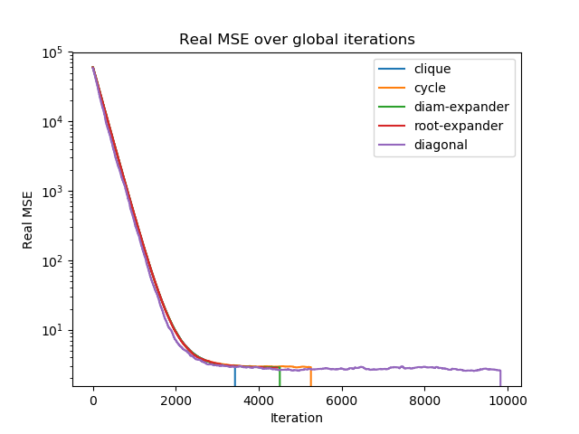

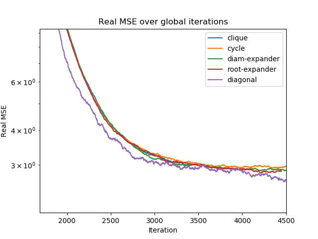

### 1k samples SGD test - MSE over time

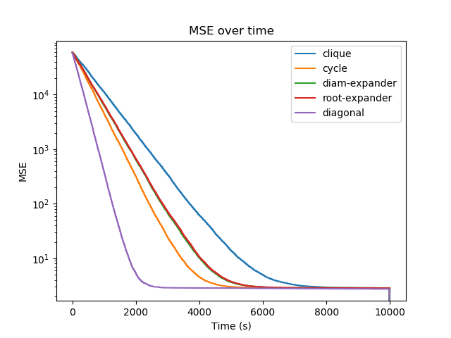

### 1k samples SGD test - RMSE over time

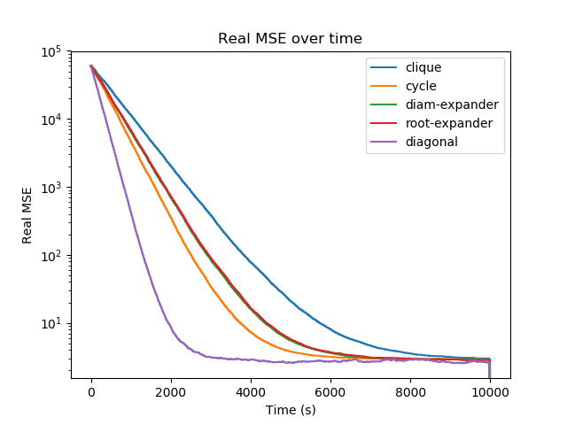

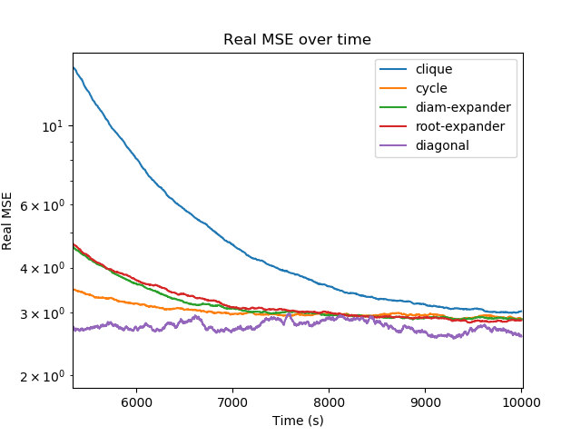

## Theoretical point of view

### Nodes' degree

We've noticed that the iterations' speed is strongly related to the number of connections established among nodes, this is clearly observable in all *iteration over time* plots. A similar speed gain can be seen in *MSE over time* plot: whether the amount of samples in the training set is big enough such that even a single node alone can achieve a good solution, then connections are just cause of slowdown. It seems that the gain in iterations' speed always matters far more than the gain in information flow due to an high dependency graph's degree. This is only a suggestion given by these early tests.

Consider the following plot (*MSE over time 10k samples GD test 003*).

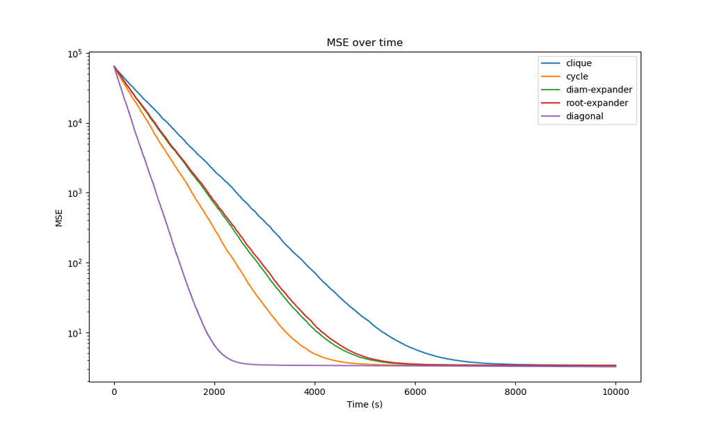

By inverting it we obtain the plot below. *NB: actually such functions aren't invertible since in small intervals the error can oscillate, anyway fixes can be applied to make them invertible (like exploiting a moving average).*

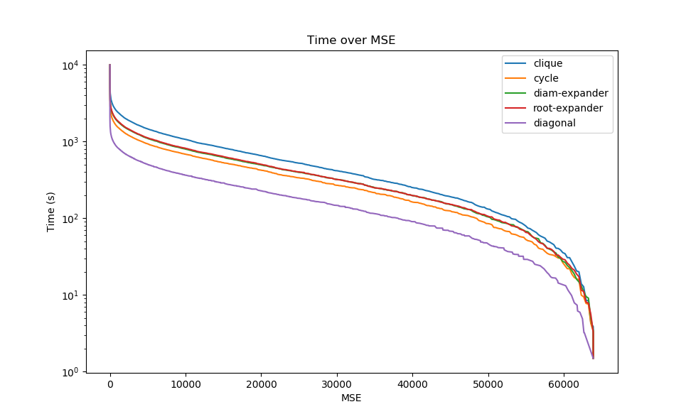

We can compare the time taken by each topology to achieve a same value of MSE, then effectively estimate the speed ratio among different topologies. The same will be done for RMSE/time, MSE/iter and RMSE/iter plots too.

### Dependency graph's diameter

Assume all nodes in the system being at iteration $r>0$, assume that one node $s$ gets stuck there (it never advances to iteration $r+1$), then:

- nodes at distance 1 from $s$ can advance only by one more iteration;
- nodes at distance 2 from $s$ can advance only by two more iterations;
- and so on, up to nodes at distance $d_s$ from $s$ (where $d_s = max\{dist(s, i) : i \in V\}$) that can advance by $d_s$ more iterations.

In general: $$ \forall i,j \in V,\ i \text{ is at iteration }r \Rightarrow j \text{ is at iteration } \in [r-dist(i,j),r+dist(i,j)] \subseteq \mathbb{N}. $$

Since $\forall i,j \in V,\ dist(i,j) \leq diam$ (where $diam$ is the graph's diameter), then the maximum distance between two nodes, with respect to iterations' number, is always less than or equal to the graph diameter. Even this property seems to be a key factor in speed gain.

For instance, the following inequality $$diam(\text{clique}) = 1 < diam(\text{diam-expander}) = \frac{n}{2} < diam(\text{cycle}) = n-1$$ holds also for the speed: the cycle is faster than the diam-expander which in turn is faster than the clique.

The questions now I am looking an answer for are:

1. how the speed is related to the nodes' degree?
2. how the speed is related to graph's diameter?
3. how much do degree and diameter weight in the observed topologies' speed? which matters more?

### System dynamic

Let $r \geq 0$ be a fixed iteration number. Let $X_1, X_2, ..., X_n$ be $n$ independent random variables where $X_i$ is the time taken by node $i$ to advance to iteration $r+1$. At the moment we consider $X_i \sim Exp(\lambda = 1)$, so

- $P(X_i \leq t) = 1-e^{-\lambda t} = 1-e^{-t}$, hence $P(X_i > t) = e^{-\lambda t} = e^{-t}$.
- $\mathbb{E}[X_i] = \frac{1}{\lambda} = 1$.

Lets define a new random variable $Z = max\{X_i : 1 \leq i \leq n\}$. $Z$ is the time taken by the slowest node to complete the $(r+1)$-th update of its weight vector, where:

- $P(Z \leq z) = \prod_{i=1}^{n} P(X_i \leq z) = (1-e^{-t})^n$;
- $\mathbb{E}[Z] = \prod_{i=1}^{n} \mathbb{E}[X_i] = (\frac{1}{\lambda})^n = 1$.

$Z$ reflects the time taken by the slowest node to perform the $(r+1)$-th weight update.

It is easy to exploit $Z$ to analyze the clique behaviour since $Z$ is exactly the time taken by each node to perform the $(r+1)$-th update of its weight. For other topologies it is not so trivial. Anyway, this is the way I will follow to give significance from a theoretical point of view to results.